### Overlap of bacteria that are associated with host modules between tissues

Now I have a graph generated for each of the tissues seperately, it is of interest to see which bacteria are associated with host modules in each tissue - there could be evidence for tissue-dependent associations or overlap in the bacteria that correlate with host gene expression. In the first instance I will look at the overlap between tissues of bacteria that are associated with ANY host module i.e. if there is a bacteria-module association it is coded as a 1 and if not then a 0. This will give a high level overview of commonalities between microbiome associations with host functions across tissues.

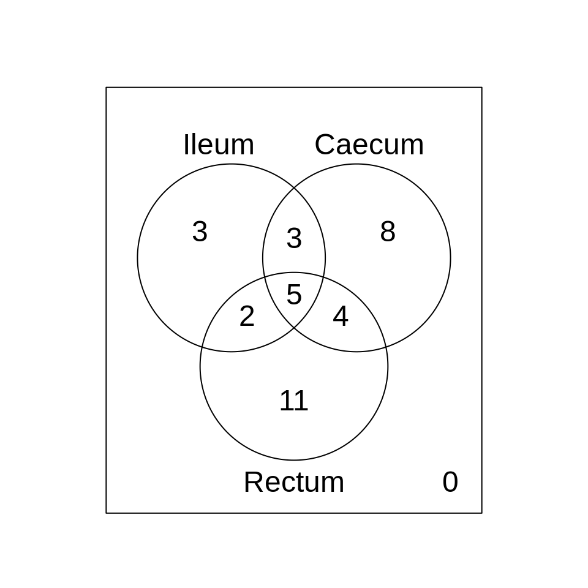

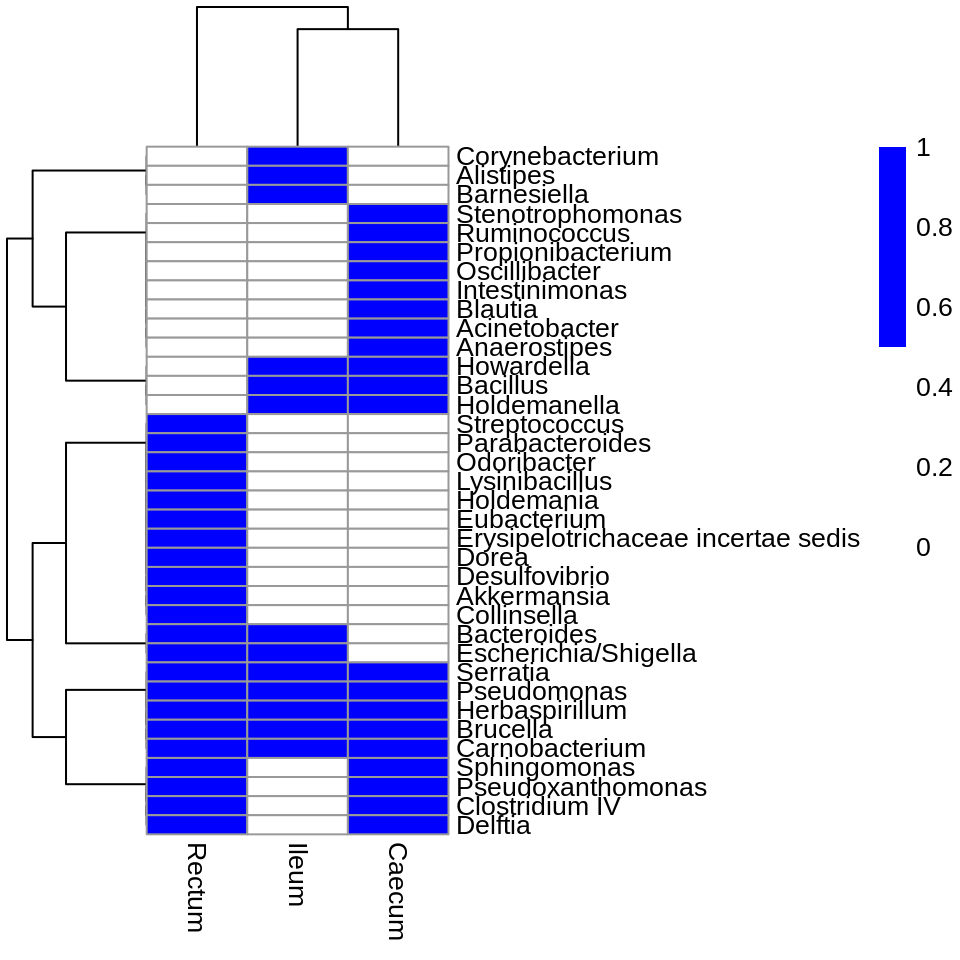

### Specific microbe-host correlations

Here I look particularly at Corynebacterium that has shown associations with host modules in the ileum.

#### Corynebacterium and module 25

Corynebacterium was associated with module 25 in the ileum. Here I look in a bit more detail as to which genes in this module are most associated.

|  | cor | p.value | padj | gene_name |
| --- | --- | --- | --- | --- |
| ENSG00000116459 | 0.7437972 | 0.0000310 | 0.0023262 | ATP5F1 |
| ENSG00000176912 | 0.7433159 | 0.0000316 | 0.0023373 | TYMSOS |
| ENSG00000183690 | 0.7024453 | 0.0001298 | 0.0094735 | EFHC2 |
| ENSG00000126432 | 0.6900762 | 0.0001903 | 0.0137042 | PRDX5 |
| ENSG00000137547 | 0.6720282 | 0.0003224 | 0.0228918 | MRPL15 |
| ENSG00000162779 | 0.6648833 | 0.0003934 | 0.0275390 | AXDND1 |
| ENSG00000169021 | 0.6546276 | 0.0005188 | 0.0358003 | UQCRFS1 |
| ENSG00000178952 | 0.6503189 | 0.0005811 | 0.0395125 | TUFM |
| ENSG00000171045 | -0.6500699 | 0.0005849 | 0.0395125 | TSNARE1 |

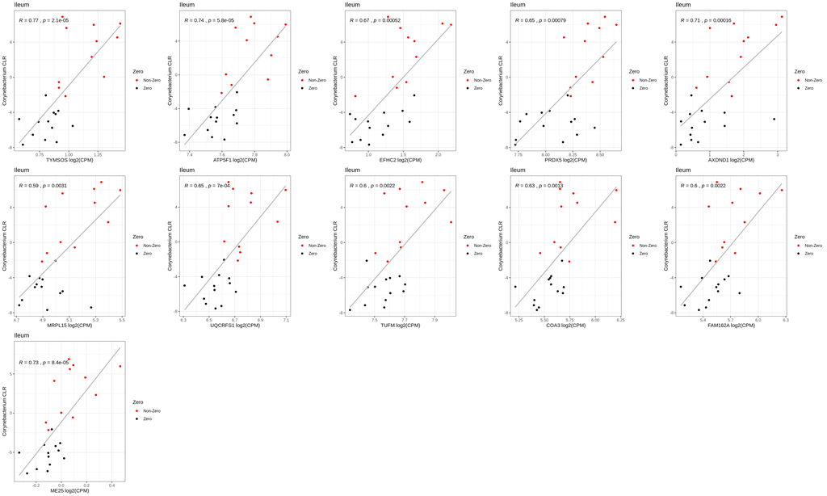

It’s clear from the plots that compare Corynebacterium abundance with specific genes in module 25 (and ME25 itself) that the distribution of corynebacterium abundance is a dichotomy - the CLR transformation may have introduced spurious correlation although there is evidence therefore that low abundance of Corynebacterium is associated with lower expression of these genes. I will have to look into slightly different approaches to look at host-microbiome associations. After some twitter discussions with Thom Quinn who is an expert in correlating microbiome data with other datasets I have decided to take two approaches:

1. Look at correlations only where there is non-zero microbial abundance data
2. re-code each genus as present/absent (or at least very low) and see if there are any significantly differentially abundant host modules between these two groups.